# Cyclists Behavioural Patterns

Nengak Emmanuel Goltong

2023-09-05

## Introduction

The director of marketing at a bike-share company believes that the company’s future success depends on maximizing the number of annual memberships. The aim of this project therefore, is to understand how behaviours differ in the two cyclist membership types.

## Reading in the Data

The Bike Share data was downloaded using this [link](https://divvy-tripdata.s3.amazonaws.com/index.html) and was further cleaned before being used for this exercise. The data cleaning is carefully documented in the accompanying file named ‘Bike-Share-Case-Study–Data-Cleaning.Rmd’.

```
## [1] "/home/spomaria/Documents/Spomary-Files/R-Scripts/Bike-Share-Study"
```

```
##
##  casual  member
## 1609290 2731087
```

## STEP 4: CONDUCT DESCRIPTIVE ANALYSIS

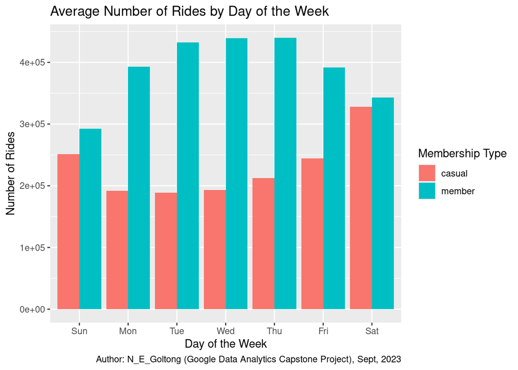

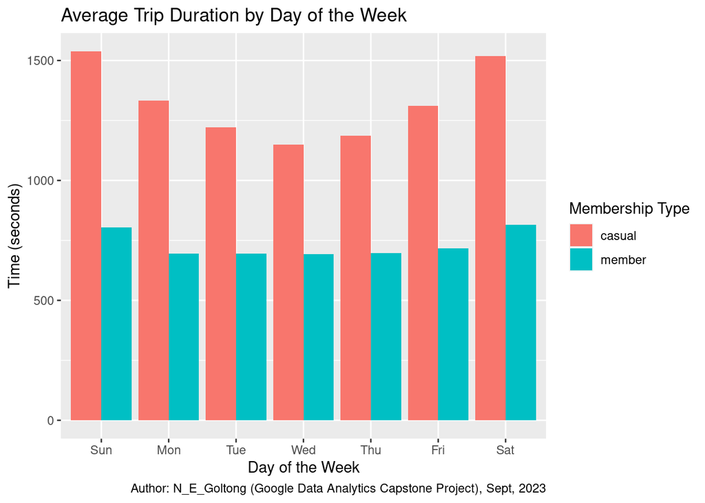

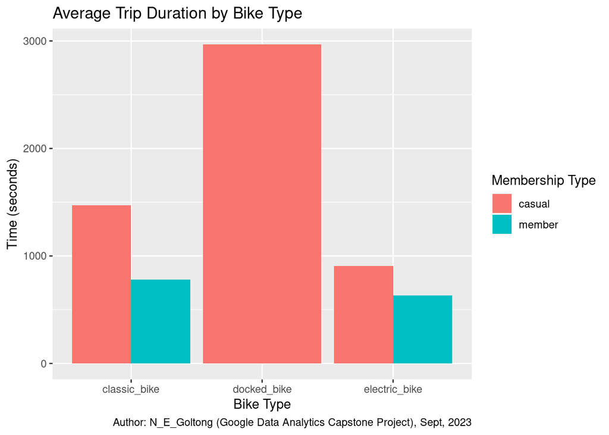

The above bar graph shows that casual members have the highest trip duration on average. In fact, those who rode on docked bike had the longest trip duration and happens that only casual members used docked bike in the period under study.

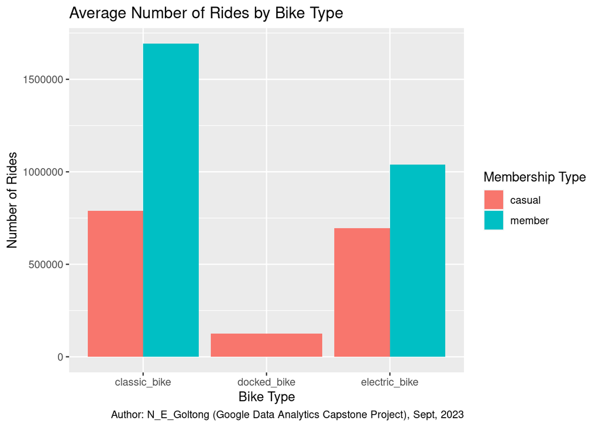

The above bar graph shows that annual members have the highest number of trips on average. In fact, those who rode on docked bike had the longest trip duration and happens that only casual members used docked bike in the period under study.

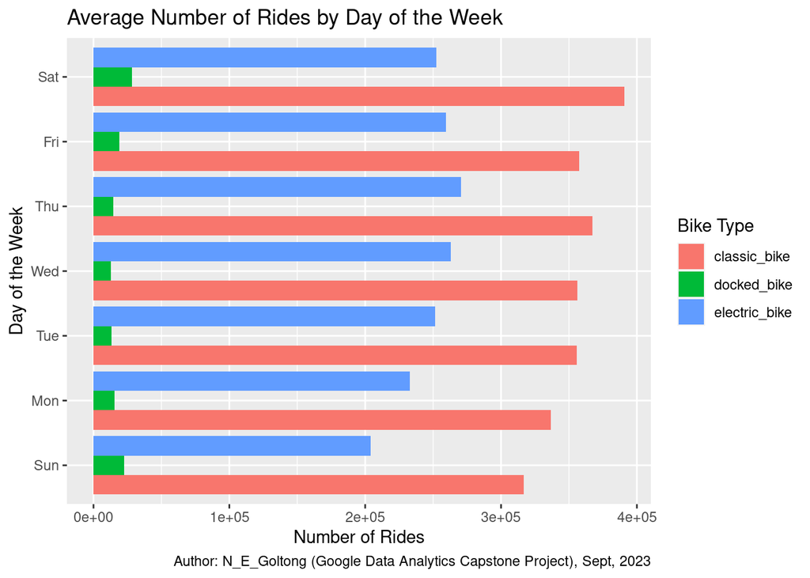

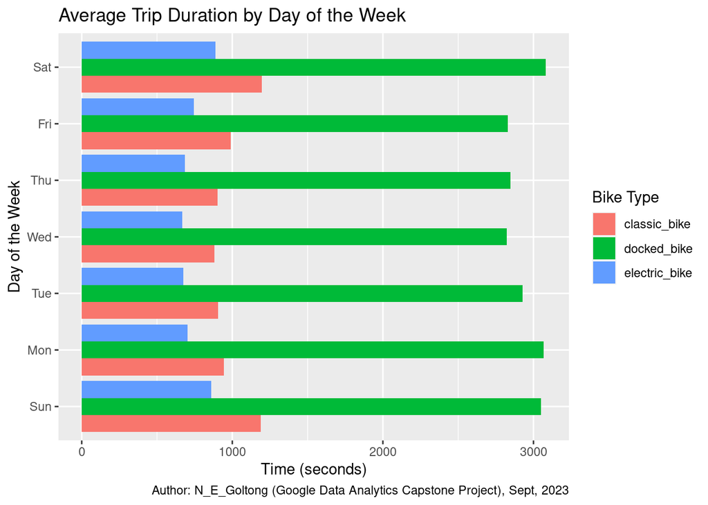

## Recomendation

In order to increase the number of annual memberships, management should consider the following actions:

1. Incorporate some discounts or some other benefits for trips with duration longer than 1,000 seconds for Annual Members.
2. Discounts should be introduced for Annual members who use docked bike type. Note that this bike type is only used by Casual members in the reporting period.
3. Discounts or incentives should be introduced for weekend trips by Annual members.